# 第一章 入门基础

## 快捷键

在code cell中按esc 再按m可以换成markdown cell

shift+回车快速运行cell

## jupyter lab 设置

### jupyter lab 自动补全设置

```python
# pip install jupyterlab-lsp
# pip install python-lsp-server pyright
# conda install r-languageserver
```

```python
# func: Code Syntax
# 启 用 或 者 关 闭 lsp 自动补全
# true 为关闭 ，false 为开启
# setting:
```

```python
{
"disable": false,
}
```

```python
# func: Language Server
# setting:
```

```python
{
    "language_servers": {
     "pyls": {
         "serverSettings": {
         "pyls.plugins.pydocstyle.enabled": true,
         "pyls.plugins.pyflakes.enabled": false,
         "pyls.plugins.flake8.enabled": true
         }
 },

       "r-languageserver": {
           "serverSettings": {
            "r.lsp.debug": false,
            "r.lsp.diagnostics": false
           }
         }
         }
 }
```

### jupyter lab 设置UI设置，变成json代码设置jupyter lab

```python
# func: Settings Editor Form UI
# setting:
```

```python
 {
"settingEditorType": "json"
 }
```

## scoop 安装与配置

scoop 为windows powershell 里安装软件神器

```python
# 进入powershell
set-alias ll # 输入ls，将Windows powershell里的ls命令改为ll

# 步骤 1:在 PowerShell 中 打 开 远 程 权 限
Set-ExecutionPolicy RemoteSigned -scope CurrentUser; #允许本地创建的脚本自由执行，但是需要远程脚本经过数字签名才能执行。
cd ~

# 步骤 2: 自定义 Scoop 安装目录
# 如 果 跳 过 该 步 骤 ， Scoop 将 默 认 把 所 有 用 户 安 装 的 App 和 Scoop
# 本身置于C:\Users\user_name\scoop
# C:\Users\vagrant
mkdir scoop ##创建一个scoop文件夹
$env:SCOOP='C:\Users\Adminisrator\scoop' #$env:SCOOP 表示一个环境变量，$env: 是 PowerShell 中用来引用环境变量的前缀
[Environment]::SetEnvironmentVariable('SCOOP', $env:SCOOP, 'User')
#这条命令的效果是将 PowerShell 中已经设置的 $env:SCOOP 环境变量的值赋给名为 SCOOP 的用户级环境变量，使得该环境变量在用户级别下全局可用

# 步骤 3:下载 并 安装 Scoop
iwr -useb https://gitee.com/glsnames/scoop-installer/raw/master/bin/install.ps1 | iex
scoop config SCOOP_REPO 'https://gitee.com/glsnames/scoop-installer' # 设置镜像( 如 果 软 件 安 装 失 败 的 话 )
scoop install git # 必 须 的 依 赖 项

#管理员运行powershell下安装scoop
irm get.scoop.sh -outfile 'install.ps1'
.\install.ps1 -RunAsAdmin
scoop install git # 必 须 的 依 赖 项

# step1: 添 加 官 方 维 护 的 extras库(含大量GUI程序)
# 国内源 scoop bucket add extras https://gitee.com/scoop−bucket/extras.git
scoop bucket add extras
# step2 更新源
scoop update

# step3 安装 App 和 命 令 行 工 具 (必装工具 , conda 装 好 可 以 不 再 装 了 )
scoop install git
scoop install miniconda3 # 安 装 全 完 全 卸 载 原 来 安 装 的 miniconda!
scoop install sudo # 调 用 管 理 员 权 限
scoop install tldr # too long dont read!,用于熟悉命令
# (类 unix 完美 ,windows 能 用 但 信 息 提 供 的 是 类 unix 的,对 windows 不 一 定 能 够 完 全 适 用 )
# 类unix 可以conda install tldr
scoop install busybox # 项 目 实 战 一 会 用 到 ! zcat命令 的 依赖
scoop install cwrsync # 项 目 实 战 一 会 用 到 !
scoop install windows-terminal #相当于windows powershell升级版
scoop install powertoys # 强力小工具
scoop install gow #用linux的一些命令在Windows powershell上使用

# 管理:
scoop list # 查 看 已 安 装 程 序
scoop status # 查看更新
scoop cleanup # 删除 旧版 本
scoop checkup # 自身诊断
```

## 变量知识点

### 不能使用关键字作为变量名

```python
import keyword


print(keyword.kwlist)
```

```
['False', 'None', 'True', 'and', 'as', 'assert', 'async', 'await', 'break', 'class', 'continue', 'def', 'del', 'elif', 'else', 'except', 'finally', 'for', 'from', 'global', 'if', 'import', 'in', 'is', 'lambda', 'nonlocal', 'not', 'or', 'pass', 'raise', 'return', 'try', 'while', 'with', 'yield']
```

```python
return = 20
```

```
  Cell In[4], line 1
    return = 20
           ^
SyntaxError: invalid syntax
```

### 默认编码与变量名

```python
# python2.* ASCII 0-127
# python3.* UTF-8 可以用中文和奇怪的字符进行命名
华男菌 = 1
print(华男菌)
β = 2
print(β)
```

```
1
2
```

### 向多个变量赋值(相同值)

```python
x = y = z = "Python"
print(x)
print(y)
print(z)
```

```
Python
Python
Python
```

### 向多个变量赋值(不同值)

```python
x, y, z = 1, 2, 3  # 解包(1, 2, 3) tuple
print(x)
print(y)
print(z)
```

```
1
2
3
```

### 问题:如何将两个变量的值互换?

#### 解法一：常规解法

```python
a = 1
b = 2

x = a  # x 1
a = b  # a 2
b = x  # b 1

print(a)
print(b)
```

```
2
1
```

#### 解法二：解包赋值

```python
a = 1
b = 2

a, b = b, a
print(a)
print(b)
```

```
2
1
```

# 第二章 内置数据类型

## 字符串: str

### 常规字符串

```python
s1 = "normal string."
print(s1)
print(type(s1))
```

```
normal string.
<class 'str'>
```

### raw 字符串

```python
s2 = r"raw \nstring"  # raw string \n不识别
s3 = "raw \nstring"  # normal string
print(s2)
print(s3)
```

```
raw \nstring
raw
string
```

```python
s4 = r"raw \tstring"  # raw string  \t不识别
s5 = "raw \tstring"  # normal string \t tab
print(s4)
print(s5)
```

```
raw \tstring
raw 	string
```

```python
# \n 换行符
# \t 制表符
```

### 三引号自动处理换行，不需要输入换行符

```python
b = "锄禾日当午，汗滴禾下土。\n锄禾日当午，汗滴禾下土。\n锄禾日当午，汗滴禾下土。\n锄禾日当午，汗滴禾下土。"
print(b)
```

```
锄禾日当午，汗滴禾下土。
锄禾日当午，汗滴禾下土。
锄禾日当午，汗滴禾下土。
锄禾日当午，汗滴禾下土。
```

```python
c = '''锄禾日当午，汗滴禾下土。
锄禾日当午，汗滴禾下土。
锄禾日当午，汗滴禾下土。
锄禾日当午，汗滴禾下土。'''
print(c)
```

```
锄禾日当午，汗滴禾下土。
锄禾日当午，汗滴禾下土。
锄禾日当午，汗滴禾下土。
锄禾日当午，汗滴禾下土。
```

### 字符串常用方法

#### find

```python
# find:从左往右找，找到第一个目标字符的序列号
#stringabc__
# 0123456789(10)
"stringabc__".find('a')
```

```
6
```

```python
#find没有的字符为-1
s = "stringabc__"
s.find('$')
```

```
-1
```

#### count

```python
# count:数目标字符数目
s = "stringabc__"
s.count("_")
```

```
2
```

#### replace

```python
# replace:替换目标字符
s = "stringabc__"
s.replace('_', '.')
```

```
'stringabc..'
```

#### startswith与endswith

```python
# startswith 判断是否目标字符开头
s = "stringabc__"
s.startswith('w')
```

```
False
```

```python
s.startswith('s')
```

```
True
```

```python
s.startswith('') #空字符串开头一定返回为true
```

```
True
```

```python
# endswith 判断是否目标字符结尾
```

#### upper与lower

```python
# upper全变为大写
# lower全变为小写
s = "stringabc__"
s.upper()
```

```
'STRINGABC__'
```

```python
s.lower()
```

```
'stringabc__'
```

#### split

```python
# split 分割字符串
s = "stringabc__"
s.split('g')
```

```
['strin', 'abc__']
```

```python
"1,2,3,4".split(",")
```

```
['1', '2', '3', '4']
```

#### join

```python
# join塞分隔符
"".join(['1', '2', '3', '4'])
```

```
'1234'
```

```python
"o".join(['1', '2', '3', '4'])
```

```
'1o2o3o4'
```

#### strip

```python
# strip 去除换行符以及空格
"\nsdasadasdasdas    \n".strip()
```

```
'sdasadasdasdas'
```

### 字符串切片(左闭右开)

#### 常规

```python
# ATGGGTCCATTTGG
# 0123456789.... # [) 左闭右开
DNA = 'ATGGGTCCATTTGG'
DNA[0:3]
```

```
'ATG'
```

#### 步长

```python
DNA = 'ATGGGTCCATTTGG'
DNA[0:5:2]
```

```
'AGG'
```

#### 反向

```python
DNA = 'ATGGGTCCATTTGG'
#         -3-2-1
DNA[-3::1]  # step 1 往右走
```

```
'TGG'
```

```python
DNA = 'ATGGGTCCATTTGG'
DNA[::-1]  # step -1 往左走
```

```
'GGTTTACCTGGGTA'
```

```python
# step >0 [) 左闭右开
# step <0 (] 右闭左开
```

### 格式化字符串:

#### %

```python
# %s被用作字符串的占位符。当你创建一个字符串时，可以使用 %s 来表示你希望在稍后插入一个字符串的地方。然后，你可以使用 % 运算符来指定你希望插入的字符串
a = "三"
b = "二"
c = "一"
s1 = "%s是%s和%s的和"
print("%s是%s和%s的和" % (a, b, c))
```

```
三是二和一的和
```

#### format 方法

```python
# format {}被用作字符串的占位符。当你创建一个字符串时，可以使用 {}来表示你希望在稍后插入一个字符串的地方。
print("{}是{}和{}的和".format(a, b, c))
```

```
三是二和一的和
```

```python
print("{}是{}和{}的和".format(a, b, c))
```

```
三是二和一的和
```

```python
print("{y}是{z}和{x}的和".format(x=a, y=b, z=c))
```

```
二是一和三的和
```

#### fstring

```python
# fstring 可以直接把之前定义的变量拿来用
```

```python
a = 3
b = 2
c = 1
print(f"{a}是{b}和{c}的和")
```

```
3是2和1的和
```

## 二进制: bytes

```python
# bytes str
b1 = b"bytes__!"
print(b1)
```

```
b'bytes__!'
```

```python
print(type(b1))
```

```
<class 'bytes'>
```

```python
# 遇到再讲！
```

## 数值型:

### int 整数

```python
# int
a = 10
print(a)
print(type(a))
```

```
10
<class 'int'>
```

### float 浮点数

```python
# float 小数
i = 6.3

print(i)
print(type(i))
```

```
6.3
<class 'float'>
```

### complex 复数

```python
# complex a + bj a 表示实部，b 表示虚部。
x = 1 + 2j
y = 1 - 2j
z = -7j
```

```python
print(x)
print(y)
print(z)
```

```
(1+2j)
(1-2j)
(-0-7j)
```

```python
x * y
```

```
(5+0j)
```

## list(中括号):

```python
ls = ['a', 'b', 'c']
ls
type(ls)
```

```
list
```

### list()

```python
t = ('a', 'b', 'c')  # tuple
type(t)
```

```
tuple
```

```python
list(t)
type(list(t))
```

```
list
```

### 更改元素

```python
ls
```

```
['a', 'b', 'c']
```

```python
ls[0] = 'x'
ls
```

```
['x', 'b', 'c']
```

### 列表常用方法

#### append

```python
# append 添加元素
ls = ['a', 'b', 'c']
ls.append("1")
ls
```

```
['a', 'b', 'c', '1']
```

#### remove

```python
#remove 删除元素 只去除一个，先去除前面那个
ls = ['a', 'b', 'c', '1']
ls.remove('1')
ls
```

```
['a', 'b', 'c']
```

#### pop

```python
#pop 把最后一个元素弹出并返回
ls = ['a', 'b', 'c']
a = ls.pop()
print(a)
print(ls)
```

```
c
['a', 'b']
```

## tuple(小括号):

```python
# tuple元素不可更改
# 因tuple不可修改，其性能会比list快
t = ("a",) #如果只有一个元素跟小括号，不然会变为字符串
y = ("a")
print(type(t))
print(type(y))
```

```
<class 'tuple'>
<class 'str'>
```

### tuple（）

```python
ls = [1, 2, 'a']
tuple(ls)
type(ls)
```

```
list
```

### 切片

```python
t = tuple('zaqsdas')
t
```

```
('z', 'a', 'q', 's', 'd', 'a', 's')
```

```python
t[1:3]
```

```
('a', 'q')
```

## range 对象

```python
range(10)  # range(0, 10) [) 左闭右开
```

```
range(0, 10)
```

```python
print(list(range(10)))
```

```
[0, 1, 2, 3, 4, 5, 6, 7, 8, 9]
```

```python
for i in range(3):
    print(i)
```

```
0
1
2
```

## 集合: set（大括号）:

- 集合是无序的：不同机器运行结果可能不同，（但是可以切片，切出来啥就不保证了）
- 不重合的

```python
st = {'a', 'b', 'c'}
print(st)
```

```
{'c', 'a', 'b'}
```

### set 函数

```python
DNA = "ATGCAATATCTTATT" #集合无顺序，不重合
set(list(DNA))
```

```
{'A', 'C', 'G', 'T'}
```

### 常用方法

#### add

```python
# add添加一个元素
st = {'A', 'C', 'G', 'T'}
st.add("U")
st
```

```
{'A', 'C', 'G', 'T', 'U'}
```

#### update

```python
# update 添加一堆元素
st = {'A', 'C', 'G', 'T'}
st.update({1, 2, 3})
st
```

```
{1, 2, 3, 'A', 'C', 'G', 'T'}
```

#### remove

```python
# remove 删除元素，删除不存在元素会报错
st = {1, 2, 3, 'A', 'C', 'G', 'T'}
st.remove(1)
st
```

```
{2, 3, 'A', 'C', 'G', 'T'}
```

#### discard

```python
# discard 删除元素，删除不存在元素不会报错
st = {1, 2, 3}
st
```

```
{1, 2, 3}
```

```python
st.discard('asdads')
st
```

[output not shown]

## 字典: dict(大括号)

```python
###{key:values}
dt = {
    'name': "herman",
    'sex': "man",
    'year': 1995
}
print(dt)
print(type(dt))
```

```
{'name': 'herman', 'sex': 'man', 'year': 1995}
<class 'dict'>
```

### dict（）

```python
#dict key不能以数字开头
dt2 = dict(
    name = "华男菌",
    sex = "man",
    year = 1995
)
print(dt2)
```

```
{'name': '华男菌', 'sex': 'man', 'year': 1995}
```

### 键值对

```python
# 访问键值对
dt={'name': 'herman', 'sex': 'man', 'year': 1995}
dt['name']
```

```
'herman'
```

```python
# 更改键值对中的值
dt={'name': 'herman', 'sex': 'man', 'year': 1995}
dt['sex'] = 'woman'
dt
```

```
{'name': 'herman', 'sex': 'woman', 'year': 1995}
```

```python
# 添加新的键值对
dt={'name': 'herman', 'sex': 'man', 'year': 1995}
dt['address'] = 'beijing'
dt
```

```
{'name': 'herman', 'sex': 'man', 'year': 1995, 'address': 'beijing'}
```

### pop

```python
# pop() 删除指定键值对并返回
dt = {'name': 'herman', 'sex': 'man', 'year': 1995, 'address': 'beijing'}
address = dt.pop('address')
print(address)
print(dt)
```

```
beijing
{'name': 'herman', 'sex': 'man', 'year': 1995}
```

### popitem

```python
# popitem 弹出最后的键值对
dt = {'name': 'herman', 'sex': 'man', 'year': 1995, 'address': 'beijing'}
dt.popitem()
```

```
('address', 'beijing')
```

## 布尔型: bool

### bool（）

```python
# 大多数值都为 True 如果有某种内容，则几乎所有值都将评估为 True
# 除空字符串外，任何字符串均为 True
# 除 0 外，任何数字均为 True
# 除空列表, 空元组外，任何列表、元组、集合和字典均为 True
print(bool("Hello"))
print(bool(1))
print(bool(0))
print(bool(""))
print(bool(()))
print(bool([]))
print(bool({}))
```

```
True
True
False
False
False
False
False
```

# 第三章 运算符

## 算术运算符

```python
print(1 + 1)
print(1 - 1)
print(1 * 1)
print(1 / 1)  # float not int!
```

```
2
0
1
1.0
```

```python
print(11 / 5)  # 除法  # 2.2
print(11 // 5)  # 取整  # 2
print(11 % 5)  # 取余  # 1
```

```
2.2
2
1
```

```python
print(5 ** 2)  # 幂运算 ^
```

```
25
```

```python
# 其他算术运算基本包含在 math 内置模块里！log,sqrt(开方)
import math
math.sqrt(25)
```

```
5.0
```

## 赋值运算符

```python
x = 1
x += 1 # x = x + 1
print(x)
x -= 1 # x = x - 1
print(x)
x *= 2 # x = x * 2
print(x)
```

```
2
1
2
```

## 比较运算符

```python
print(1 == 1)  # True
print(1 != 1)  # False !=为不等于
```

```
True
False
```

```python
print(1 > 2)
print(1 < 2)
print(1 >= 2)
print(1 <= 1)
```

```
False
True
False
True
```

```python
# ？？？
print('a' < 'b')
print('a' < 'A')
print('a' > 'A')
```

```
True
False
True
```

```python
# 字符串基于 ASCII 码值大小的比较
# ord() 把字符串转为ascii
print(ord('a'))
print(ord('A'))

# chr() ascii转为字符串
print(chr(65))
```

```
97
65
A
```

## 逻辑运算符

- 与或非
- and or not

```python
# and 两个为真才为真
print(True and True)
print(True and False)
print(False and True)
print(False and False)
```

```
True
False
False
False
```

```python
# or 一个为真就为真
print(True or True)
print(True or False)
print(False or True)
print(False or False)
```

```
True
True
True
False
```

```python
# nor取反
print(not False)
print(not True)
```

```
True
False
```

## 身份运算符

- is
- is和==的区别！

```python
# id() 查看变量的内存地址
x = [1, 2, [3, 4]]
y = x
print(id(x))
print(id(y))

print(x == y)  # True
print(x is y)  # True  # 判断两个变量代表的值的内存地址是否相同的
```

```
2792005702528
2792005702528
True
True
```

```python
x = [1, 2, [3, 4]]
y = [1, 2, [3, 4]]
print(id(x))
print(id(y))

print(x == y)  # True
print(x is y)  # False  # is判断两个变量代表的值的内存地址是否相同的
```

```
4582319744
4582305216
True
False
```

## 成员运算符

- in
- not in

```python
# in 某个元素在不在某个数据里
ls = [1, 2, 3]
s = 'asdasdadaas'
print('a' in ls)  # F
print(1 in ls)  # T
print(1 not in ls)  # F
print('a' in s)  # T
print('a' not in s)  # F
```

```
False
True
False
True
False
```

```python
# %%timeit运算很多次，来来评估某个cell的性能 ，只能在jupyer中使用
```

```python
%%timeit
'sd' in s
```

```
23.4 ns ± 0.211 ns per loop (mean ± std. dev. of 7 runs, 10,000,000 loops each)
```

```python
%%timeit
s.find('sd')
```

```
86.4 ns ± 1.26 ns per loop (mean ± std. dev. of 7 runs, 10,000,000 loops each)
```

## 海象运算符 (:=)

for looop 中讲解

# 第四章 流程控制

## 顺序结构

```python
# 常规的代码就是顺序结构一句一句自上而下执行！
# 顺序结构！
```

## 分支结构——判断

### if

```python
# if
a = 'x'

if a == 1:  # False，不成立下面不运行
    print('a = 1')
```

```python
if a == 'x':  # True
    print('a = x')
```

```
a = x
```

### if else

```python
# if else
# 如果条件不满足，就执行 else 语句
a = 'a'
b = 'b'

if a == b:  # F
    print('a = b')
else:
    print(a, b)
```

```
a b
```

### if elif else

```python
# if elif else...
a = 'x'
if a == 'a':
    print('a')
elif a == 'b':
    print('b')
elif a == 'c':
    print('c')
else:
    print(a)
```

```
x
```

## 循环结构

### while loop

```
while 条件为True:
    run ....
```

```python
import time
while 1 == 1:
    print(time.localtime())
    time.sleep(1)
```

```
time.struct_time(tm_year=2022, tm_mon=9, tm_mday=18, tm_hour=11, tm_min=53, tm_sec=31, tm_wday=6, tm_yday=261, tm_isdst=0)
time.struct_time(tm_year=2022, tm_mon=9, tm_mday=18, tm_hour=11, tm_min=53, tm_sec=32, tm_wday=6, tm_yday=261, tm_isdst=0)
time.struct_time(tm_year=2022, tm_mon=9, tm_mday=18, tm_hour=11, tm_min=53, tm_sec=33, tm_wday=6, tm_yday=261, tm_isdst=0)
time.struct_time(tm_year=2022, tm_mon=9, tm_mday=18, tm_hour=11, tm_min=53, tm_sec=34, tm_wday=6, tm_yday=261, tm_isdst=0)
time.struct_time(tm_year=2022, tm_mon=9, tm_mday=18, tm_hour=11, tm_min=53, tm_sec=35, tm_wday=6, tm_yday=261, tm_isdst=0)
time.struct_time(tm_year=2022, tm_mon=9, tm_mday=18, tm_hour=11, tm_min=53, tm_sec=36, tm_wday=6, tm_yday=261, tm_isdst=0)
time.struct_time(tm_year=2022, tm_mon=9, tm_mday=18, tm_hour=11, tm_min=53, tm_sec=37, tm_wday=6, tm_yday=261, tm_isdst=0)
time.struct_time(tm_year=2022, tm_mon=9, tm_mday=18, tm_hour=11, tm_min=53, tm_sec=38, tm_wday=6, tm_yday=261, tm_isdst=0)
time.struct_time(tm_year=2022, tm_mon=9, tm_mday=18, tm_hour=11, tm_min=53, tm_sec=39, tm_wday=6, tm_yday=261, tm_isdst=0)
time.struct_time(tm_year=2022, tm_mon=9, tm_mday=18, tm_hour=11, tm_min=53, tm_sec=40, tm_wday=6, tm_yday=261, tm_isdst=0)
time.struct_time(tm_year=2022, tm_mon=9, tm_mday=18, tm_hour=11, tm_min=53, tm_sec=41, tm_wday=6, tm_yday=261, tm_isdst=0)
time.struct_time(tm_year=2022, tm_mon=9, tm_mday=18, tm_hour=11, tm_min=53, tm_sec=42, tm_wday=6, tm_yday=261, tm_isdst=0)
time.struct_time(tm_year=2022, tm_mon=9, tm_mday=18, tm_hour=11, tm_min=53, tm_sec=43, tm_wday=6, tm_yday=261, tm_isdst=0)
time.struct_time(tm_year=2022, tm_mon=9, tm_mday=18, tm_hour=11, tm_min=53, tm_sec=44, tm_wday=6, tm_yday=261, tm_isdst=0)
time.struct_time(tm_year=2022, tm_mon=9, tm_mday=18, tm_hour=11, tm_min=53, tm_sec=45, tm_wday=6, tm_yday=261, tm_isdst=0)
time.struct_time(tm_year=2022, tm_mon=9, tm_mday=18, tm_hour=11, tm_min=53, tm_sec=46, tm_wday=6, tm_yday=261, tm_isdst=0)
time.struct_time(tm_year=2022, tm_mon=9, tm_mday=18, tm_hour=11, tm_min=53, tm_sec=47, tm_wday=6, tm_yday=261, tm_isdst=0)
time.struct_time(tm_year=2022, tm_mon=9, tm_mday=18, tm_hour=11, tm_min=53, tm_sec=48, tm_wday=6, tm_yday=261, tm_isdst=0)
```

```
---------------------------------------------------------------------------
KeyboardInterrupt                         Traceback (most recent call last)
/var/folders/3_/d_372pfd2tq8dblwgczv4s_00000gn/T/ipykernel_5061/3988897327.py in <cell line: 4>()
      4 while 1 == 1:
      5     print(time.localtime())
----> 6     time.sleep(1)

KeyboardInterrupt:
```

```python
s = 0

while s < 5:
    print(time.localtime())
    time.sleep(1)
    s += 1
    print(s)
print('!')
```

```
time.struct_time(tm_year=2022, tm_mon=9, tm_mday=18, tm_hour=12, tm_min=0, tm_sec=52, tm_wday=6, tm_yday=261, tm_isdst=0)
1
time.struct_time(tm_year=2022, tm_mon=9, tm_mday=18, tm_hour=12, tm_min=0, tm_sec=53, tm_wday=6, tm_yday=261, tm_isdst=0)
2
time.struct_time(tm_year=2022, tm_mon=9, tm_mday=18, tm_hour=12, tm_min=0, tm_sec=54, tm_wday=6, tm_yday=261, tm_isdst=0)
3
time.struct_time(tm_year=2022, tm_mon=9, tm_mday=18, tm_hour=12, tm_min=0, tm_sec=55, tm_wday=6, tm_yday=261, tm_isdst=0)
4
time.struct_time(tm_year=2022, tm_mon=9, tm_mday=18, tm_hour=12, tm_min=0, tm_sec=56, tm_wday=6, tm_yday=261, tm_isdst=0)
5
!
```

```python
s = 0

while s < 5:
    print(time.localtime())
    time.sleep(1)
    s += 1
    print(s)
    break #表中断
print('!')
```

```
time.struct_time(tm_year=2022, tm_mon=9, tm_mday=18, tm_hour=12, tm_min=1, tm_sec=18, tm_wday=6, tm_yday=261, tm_isdst=0)
1
!
```

### for loop

```python
s = 'xyz'
for i in s:
    print(i)
    if i == 'y':
        break
```

```
x
y
```

## dict 遍历

#### dict 遍历键

```python
dt = {
    'name': '华男菌',
    'sex': 'man',
    'year': 1995
}
dt
```

```
{'name': '华男菌', 'sex': 'man', 'year': 1995}
```

```python
for k in dt:
    print(k)
```

```
name
sex
year
```

#### dict 遍历值

```python
for k in dt.values():
    print(k)
```

```
华男菌
man
1995
```

#### dict 遍历键值对

```python
for k, v in dt.items():
    print(f'key is {k}, value is {v}')
```

```
key is name, value is 华男菌
key is sex, value is man
key is year, value is 1995
```

## 海象操作符！

```python
s = 'asdsssssssssss'
```

```python
n = len(s)  # 14

if n > 10:
    print(n)
```

```
14
```

```python
# 海象操作符 :=
# 1 判断
# 2 赋值
```

```python
if (n:=len(s)) > 10: #len(s)如果大于10，就将len(s)赋值给n
    print(n)
```

```
14
```

## 练习:九九乘法表

```python
for i in range(1, 10):
    for j in range(1, i + 1):
        print(f'{i} x {j} = {i * j}', end=' ') #print参数原来的end="/n",每次打印都会换行
    print() #空的print相当于换行
```

```
1 x 1 = 1
2 x 1 = 2 2 x 2 = 4
3 x 1 = 3 3 x 2 = 6 3 x 3 = 9
4 x 1 = 4 4 x 2 = 8 4 x 3 = 12 4 x 4 = 16
5 x 1 = 5 5 x 2 = 10 5 x 3 = 15 5 x 4 = 20 5 x 5 = 25
6 x 1 = 6 6 x 2 = 12 6 x 3 = 18 6 x 4 = 24 6 x 5 = 30 6 x 6 = 36
7 x 1 = 7 7 x 2 = 14 7 x 3 = 21 7 x 4 = 28 7 x 5 = 35 7 x 6 = 42 7 x 7 = 49
8 x 1 = 8 8 x 2 = 16 8 x 3 = 24 8 x 4 = 32 8 x 5 = 40 8 x 6 = 48 8 x 7 = 56 8 x 8 = 64
9 x 1 = 9 9 x 2 = 18 9 x 3 = 27 9 x 4 = 36 9 x 5 = 45 9 x 6 = 54 9 x 7 = 63 9 x 8 = 72 9 x 9 = 81
```

```python
# format method
# fsting
for i in range(1, 10):
    for j in range(1, i + 1):
        print(f'{i:>3}  x{j:>3} ={i * j:>2}', end=' ') #:>为占位符，占3个，如果不足，空格来补
    print()
```

```
  1  x  1 = 1
  2  x  1 = 2   2  x  2 = 4
  3  x  1 = 3   3  x  2 = 6   3  x  3 = 9
  4  x  1 = 4   4  x  2 = 8   4  x  3 =12   4  x  4 =16
  5  x  1 = 5   5  x  2 =10   5  x  3 =15   5  x  4 =20   5  x  5 =25
  6  x  1 = 6   6  x  2 =12   6  x  3 =18   6  x  4 =24   6  x  5 =30   6  x  6 =36
  7  x  1 = 7   7  x  2 =14   7  x  3 =21   7  x  4 =28   7  x  5 =35   7  x  6 =42   7  x  7 =49
  8  x  1 = 8   8  x  2 =16   8  x  3 =24   8  x  4 =32   8  x  5 =40   8  x  6 =48   8  x  7 =56   8  x  8 =64
  9  x  1 = 9   9  x  2 =18   9  x  3 =27   9  x  4 =36   9  x  5 =45   9  x  6 =54   9  x  7 =63   9  x  8 =72   9  x  9 =81
```

# 第五章 pycharm

## 推荐插件

```python
# CodeGlance3  code minimap
```

```python
# Key Promoter X 是一个提示插件，当你在IDEA里面使用鼠标的时候
# 如果这个鼠标操作是能够用快捷键替代的，那么Key Promoter X会弹出一个提示框，告知你这个鼠标操作可以用什么快捷键替代
```

```python
# Json Parser json方便查看工具
```

```python
#  Rainbow Brackets 彩虹色的括号 要钱了
#   Rainbow CSV 彩虹色的逗号
```

```python
# Chinese (Simplified) Language Pack / 中文语言包
```

## 扩展工具

### AutoPep8

```python
# conda install autopep8
```

autopep8是一个开源的命令行工具，它能够将Python代码自动格式化为PEP8风格 Name: AutoPep8 Description: autopep8 your code Program: autopep8 Arguments: --in-place --aggressive --aggressive $FilePath$ Working directory: $ProjectFileDir$ Output filters: $FILE_PATH$\:$LINE$\:$COLUMN$\:.*

# 第六章 模块与包

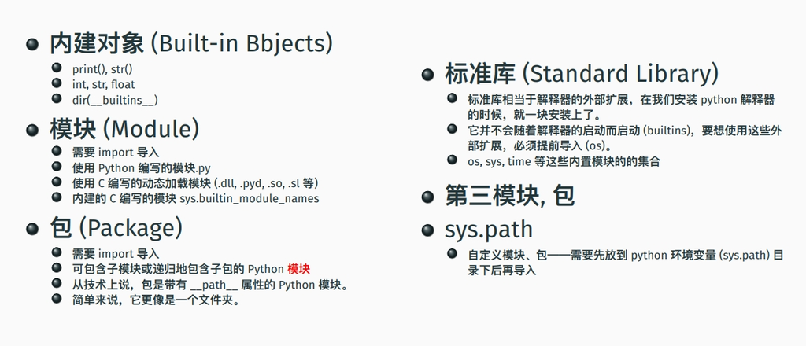

## 主程序与模块

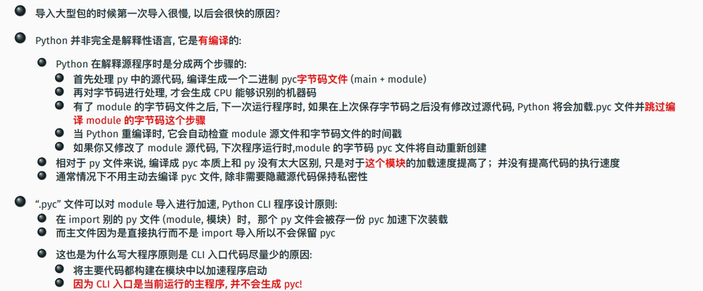

# 第七章 异常处理

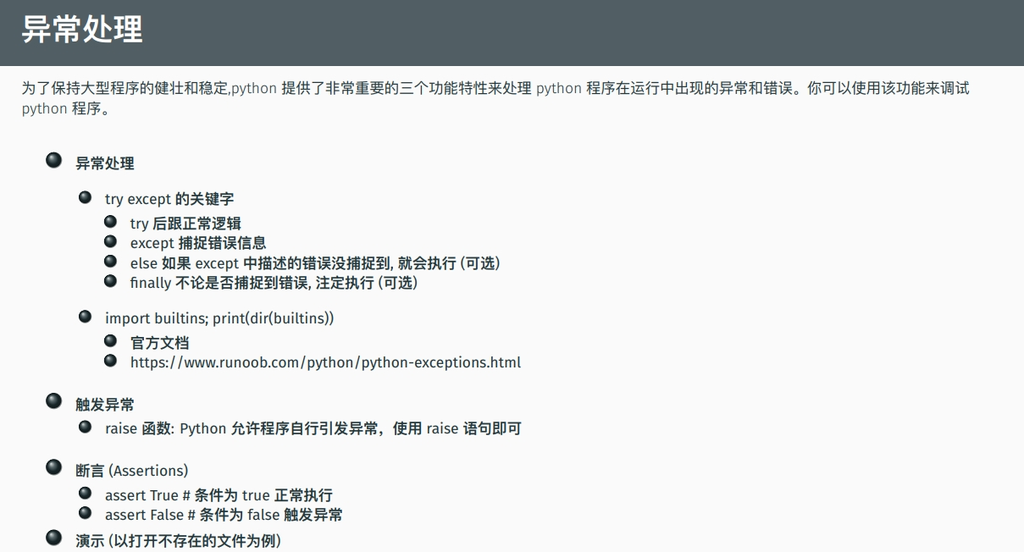

```python
import os


file = './adsawsasddass.txt'
try:
    f = open(file, 'xt') # 读取一个文件，没有会创建
except FileExistsError:
# 只用except：则无论什么错误都能捕捉到，建议放在其他except error，这样其他的error有对应的处理
    while True:
        op = input("这个文件已经存在了，是否删除(y/Y,n/N)")

        if op in ('y', 'Y'):
            os.remove(file)  # 删除文件
            break
        elif op in ('n', "N"):
            print("用户选择不删除，终止程序!")
            exit(0)  # 正常退出,可以填1，1为错误代码，不同的错误代码代表不同意思
        else:
            print("用户操作错误")
            continue
finally: #无论是否错误，一定会执行
    print("lll")
print("继续往下走")

#文件打开后即使关闭，不关闭文件会导致内存没有及时释放，循环次数多会导致卡死
```

```
用户选择不删除，终止程序!
```

```
lll
```

[output not shown]

# 第八章 面向对象编程

## 介绍

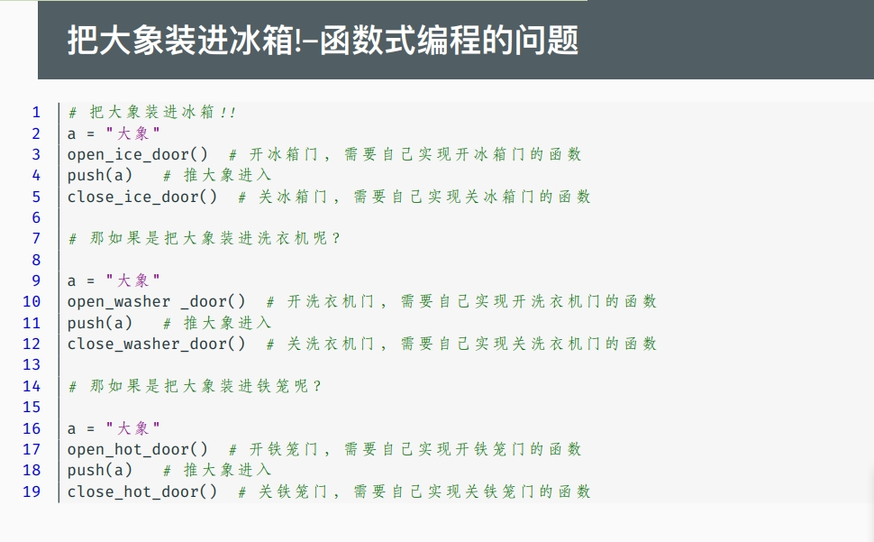

R 是一个函数式编程的语言 (大象装进冰箱的弊端!) Java 完全面向对象 Python 既可以以函数式编程方式写程序, 也可以以面向对象编程方式写程序! 如果你以前没有接触过面向对象的编程语言, 那你可能需要先了解一些面向对象语言的一些基本特征, 在头脑里头形成一个基本的面向对象的概念, 这样 有助于你更容易的学习 Python 的面向对象编程。 接下来我们先来简单的了解下面向对象的一些基本特征。 对象? 几只胳膊 (属性, 名词) 几条腿 (属性, 名词) 打人, 吃饭 (方法, 动词) 大象装进? 里面 (冰箱, 洗机器, 铁笼) 对象都是容器 (属性) 对象都有 open_door(方法) 对象都有 close_door(方法) 对象都有 push(方法

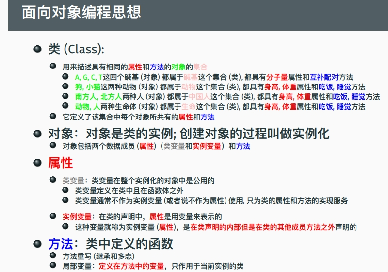

```python
先定义一类“盒子”的函数，再有class，就可以将某个对象继承某个类“盒子”的函数
```

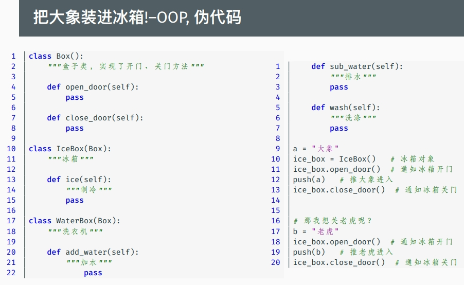

## 面向对象编程——碱基互补配对例子

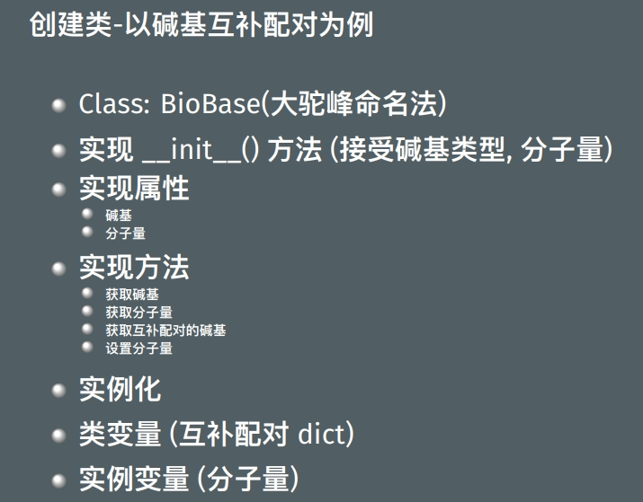

### 前置学习

#### zip函数

```python
# zip会把两个向量压缩
a=(1,2,3)
b=("a","b","c")
print(list(zip(a,b)))

{k:v for k,v in zip("AGCTU","TCGAA")}
```

```
[(1, 'a'), (2, 'b'), (3, 'c')]
```

```
{'A': 'T', 'G': 'C', 'C': 'G', 'T': 'A', 'U': 'A'}
```

### 操作

```python
class BioBase:   # 大驼峰命名法,单词开头为大写，方便辨认
    """"THIS IS A BIOBASE CLASS""" # 类注释

    PAIR={k:v for k,v in zip("AGCTU","TCGAA")}
    # 一个不基本改变的变量，建议用大写，放在误修
    # 这个也为类变量，后面函数也要用self.PAIR来访问
    # 可以变量加2个下划线__PAIR，让变量隐藏，其在类外面不能访问
    # 变量前加单个下划线_PAIR,则虽然我可以被访问，但是，请把我视为私有变量，不要随意访问”。

    def __init__(self,base,weight=None): # 属性
        self.base = base
        self.weight = weight

    def get_base(self):# 获取碱基
        return self.base

    def get_weight(self):#获取分子量
        return self.weight

    def get_paired_base(self):#获取碱基互补配对
        return self.PAIR[self.base]

    def set_weight(self,weight):#设置分子量
        self.weight = weight

mybase = BioBase(base="A",weight=100)  #实例化
print(mybase)
print(type(mybase))

print(mybase.base)
print(mybase.weight)

print(mybase.get_base())
print(mybase.get_weight())

print(mybase.get_paired_base())

mybase.set_weight(200)
print(mybase.get_weight())
```

```
<__main__.BioBase object at 0x0000026C8DD70DD0>
<class '__main__.BioBase'>
A
100
A
100
T
200
```

## 继承与多态

例如：把大象放进不同的盒子里

```python
class Box():
    """father class"""

    def __repr__(self):
        return "Box"
    # 可以重新定义__repr__(self)，让push返回class没有内存地址

    def __init__(self,a):#实例化时赋值过来
        self.a=a

    def open_door(self):
        print("开门")

    def close_door(self):
        print("关门")

    def push(self):
        print(f"{self.a}放进{self.__repr__()}")
        # self.__repr__()没有重新定义
        # 则为实例化class名称加内存地址

box=Box(a="大象") ##实例化对象
box.open_door()
box.push()
box.close_door()
```

```
开门
大象放进Box
关门
```

```python
class IceBox(Box):
    # 从BOX这一类继承属性,IceBox将会拥有Box所有方法
    """"sub class"""

    def __repr__(self):
        return "IceBox"

    def ice(self):
        print("冷冻")

    def cool(self):
        print("冷藏")

box2=IceBox(a="大象")
box2.open_door()
box2.push()
box2.ice()
box2.cool()
box2.close_door()
```

```
开门
大象放进IceBox
冷冻
冷藏
关门
```

```python
class WaterBox(Box):
    """"sub class"""

    def __repr__(self):
        return f'WaterBox_belongs_to{super().__repr__()}'
    #super().__repr__() 为 father class

    def add_water(self):
        print("加水")

    def sub_water(self):
        print("排水")

    def water(self):
        print("洗衣服")

box3=WaterBox(a="大象")
box3.open_door()
box3.push()
box3.add_water()
box3.water()
box3.sub_water()
box3.close_door()
```

```
开门
大象放进WaterBox_belongs_toBox
加水
洗衣服
排水
关门
```